# Boston Health Inspections: Geospatial Analysis

2025-12-31

```r
library(tidyverse)
library(sf)
library(lubridate)
library(viridis)

# Load the single, final clean file
inspections <- read_csv("data/inspections_clean.csv")
```

### Boston Zipcodes Map

```r
bos_insp <- inspections |>
  filter(city_source == "Boston")
bos <- st_read("data/Boston Shapefiles/ZIP_Codes.shp")
```

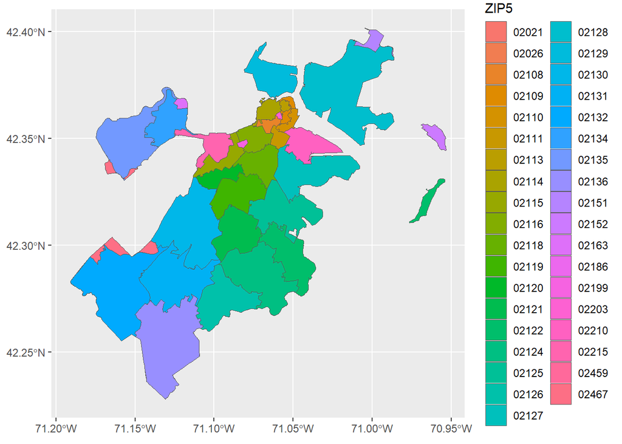

```r
bos_borders <- bos |> st_union() |>
  st_buffer(.5)
ggplot(bos_borders) +
  geom_sf(data=bos, aes(fill = ZIP5))
```

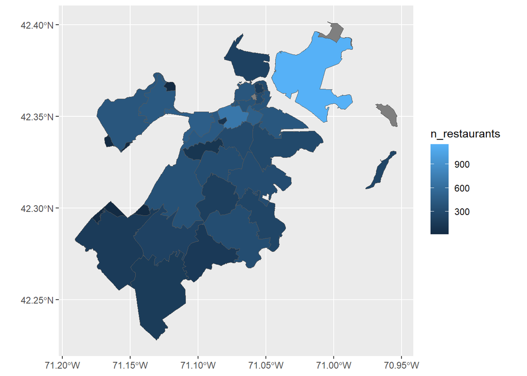

```r
# Density map of restaurants per zipcode

rstnt_density <- bos_insp |>
  group_by(zip_code) |>
  summarize(n_restaurants = n_distinct(restaurant_name))

bos <- bos |>
  rename(zip_code = ZIP5)

bos_joined <- left_join(bos, rstnt_density, by = "zip_code")

ggplot(bos_borders) +
  geom_sf(data=bos_joined, aes(fill = n_restaurants))
```

## Analysis

I would like to investigate the geographic distribution of different aspects of the health code inspections in Boston. To do this, I will isolate all of the Boston health inspection records and map several factors of the data onto a map of the City of Boston, separated by zipcode subsection.

We have a restaurant density map already from EDA, but I want to be more specific and see what the restaurant hotspots are in the city.

```r
# Group by all of the different restaurants, using addresses due to the fact that the same restaurant may be spelled slightly differently by different inspectors.

bos_insp <- inspections |>
  filter(city_source == "Boston")
bos <- st_read("data/Boston Shapefiles/ZIP_Codes.shp")
```

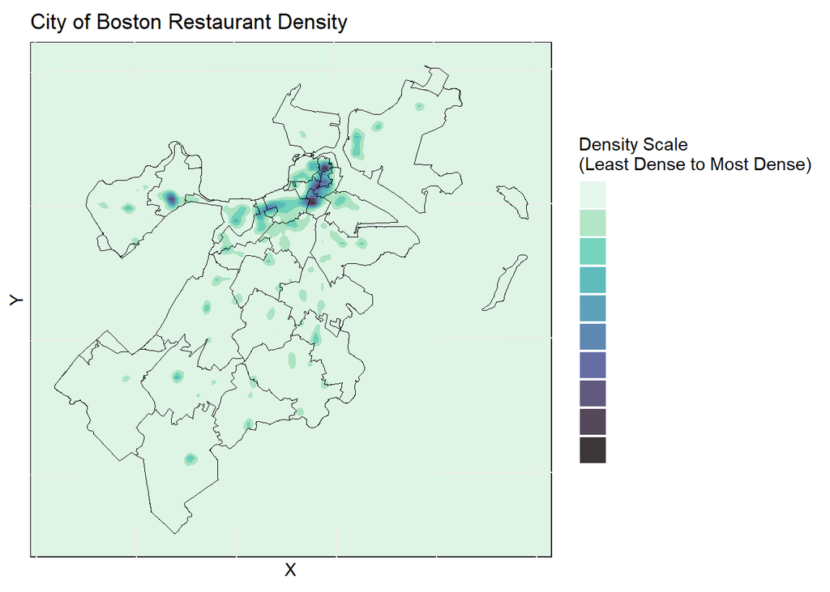

```r
bos_borders <- bos |> st_union() |>
  st_buffer(.5)

###### ^^^^ Upload Shapefiles (same as EDA) ######


# Condense relevant data and reformat latitude and longitude. Airport restaurant coordinates seem to have been recorded wrong (showing up in atlantic ocean). Filter them out.


ind_rsts <- bos_insp |>
  distinct(address_full, .keep_all = TRUE) |>
  mutate(coords_clean = str_remove_all(location_string, "[()]"))|>
  separate(coords_clean, into = c("lat", "lon"), sep = ",", convert = T) |>
  mutate (
    lat = as.numeric(lat),
    lon = as.numeric(lon)
  ) |>
  drop_na(lat,lon) |>
  filter(
    lat > 41, lat < 42.8,
    lon > -71.8, lon < -70.7
  ) |>
  select(restaurant_name, address_full, lat, lon)


coords_sf <- ind_rsts |>
  st_as_sf(coords = c("lon", "lat"), crs = 4326) |>
  st_transform(26986)


bos <- bos |>
  st_transform(26986)

df_coords <- as.data.frame(st_coordinates(coords_sf))

ggplot() +
  geom_density_2d_filled(
    data = df_coords,
    aes(X, Y, fill = ..level..),
    contour_var = "ndensity",
    alpha = 0.8,
    h = c(500, 500),
    clip = "on"
  ) +
  scale_fill_viridis_d(option = "mako", direction = -1, labels = NULL) +
  theme_minimal() +
  labs(title = "City of Boston Restaurant Density",
       fill = "Density Scale\n(Least Dense to Most Dense)") +
  geom_sf(data = bos, fill = NA, color = "black", size = 0.05) +
  theme(panel.background = element_rect(fill = "#DEF5E5FF"),
        axis.text = element_blank(),
        theme(axis.title = element_blank()))
```

As we can see, there are hotspots near Harvard Ave in Allston, the North End, Downtown Crossing, Chinatown, and Newbury St.

**Suburban vs. Urban restaurants**

Urban: Has more than or equal to **10** other restaurants within a **100 meter** radius.

Suburban: Has less than **10** other restaurants within a **100 meter** radius.

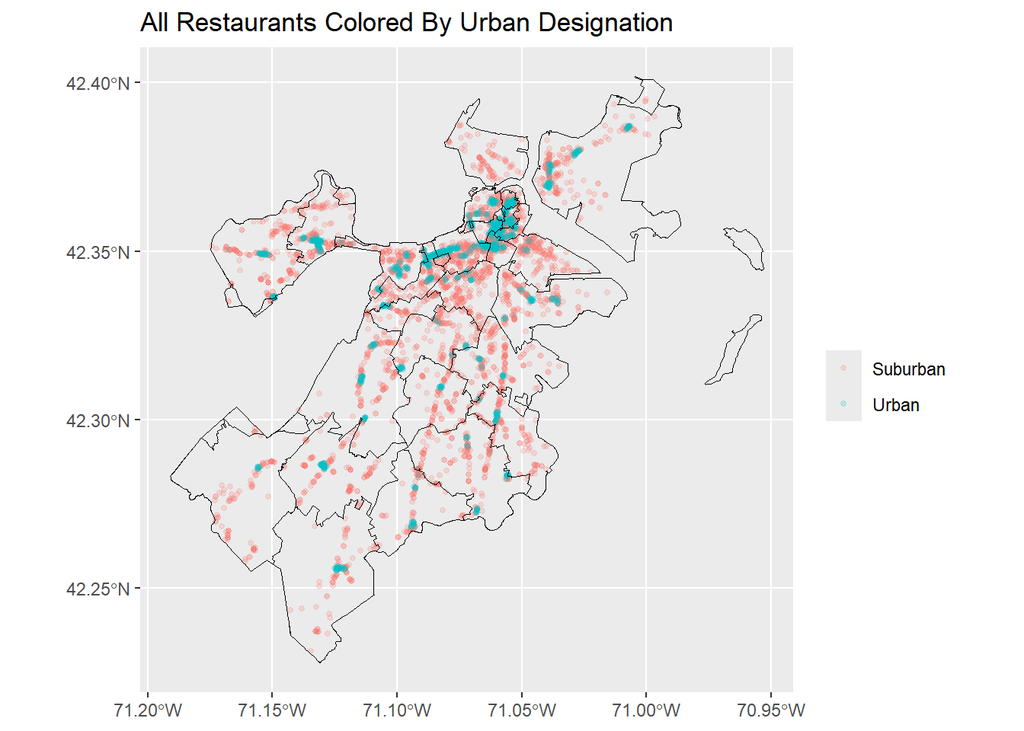

```r
# Create circles around each rst

buffer <- st_buffer(coords_sf$geometry, dist = 100)

int <- st_intersects(buffer, coords_sf |> select(geometry))

# Count how many row joins per buffer

n_int <- lengths(int)

# I want the index of all of the restaurants that have more than x amount of restaurants in this radius

ind_rsts <- ind_rsts |>
  mutate(
    n_neighbor = n_int - 1,
    urban_yn = (n_int - 1) >= 10
  )

ind_rsts <- st_as_sf(ind_rsts, coords = c("lon", "lat"), crs = 4326)


# Now lets plot all of the restaurants with their new designations

ggplot() +
  geom_sf(data = ind_rsts,
          aes(color = urban_yn),
          size = 1,
          alpha = 0.2) +
  geom_sf(data = bos, fill = NA, color = "black") +
  labs(
    title = "All Restaurants Colored By Urban Designation",
    color = ""
  ) +
  scale_color_discrete(
    labels = c("TRUE" = "Urban", "FALSE" = "Suburban")
  )
```

**Hypothesis Tests**

Now that we’ve designated each restaurant as Urban or Rural, we can run some hypothesis tests.

Do urban or suburban restaurants have more failed health inspections? Is this difference significant?

```r
#Expand individual restaurants and their urban/suburban designation to the full inspection report

ind_rsts <- ind_rsts |>
  mutate(
    urban_bucket = (n_int - 1) >= 10
  )


new_bos_insp <- bos_insp |>
  left_join(
    ind_rsts |>
      st_drop_geometry() |>
      select(address_full, urban_yn, n_neighbor),
    by = "address_full"
  ) |>
  filter(
    !if_any(c(urban_yn,viol_status), ~is.na(.))
  )


library("janitor")
new_bos_insp |>
  tabyl(urban_yn, viol_status) |>
  adorn_totals("row") |>
  adorn_percentages("row") |>
  adorn_pct_formatting(digits = 1)
```

|  | urban_yn | Fail | Pass |
| --- | --- | --- | --- |
| 1 | FALSE | 55.6% | 44.4% |
| 2 | TRUE | 54.8% | 45.2% |
| 3 | Total | 55.3% | 44.7% |

```r
chisq.test(table(new_bos_insp$viol_status, new_bos_insp$urban_yn))
```

```
##
##  Pearson's Chi-squared test with Yates' continuity correction
##
## data:  table(new_bos_insp$viol_status, new_bos_insp$urban_yn)
## X-squared = 38.029, df = 1, p-value = 6.969e-10
```

This proportion table with marginal proportions shows us that Pass Rate for Urban restaurants is 0.8% higher than for Suburban restaurants. This means that suburban restaurants tend to fail health inspections more often than urban restaurants.

To see whether this result is significant, we can conduct a Chi-Squared Test for independence. These are the assumptions:

- Both Urban/Suburban status and Pass/Fail reports must be categorical variables with 2+ distinct groups
- Categories within each designation must be mutually exclusive.
- Each health inspection report must be independent of the others.
- There must be more than 5 reports in each of the 4 categories.

With a p-value of 6.969x10^-10, we can reject the null hypothesis that the categories are independent from each another. We have evidence that Urban/Suburban designation and health inspection pass rates are dependent on one another.

Now let’s try to visualize this trend by plotting all of the restaurants and their inspection pass rates.

```r
summary(ind_rsts$n_neighbor)
```

```
##    Min. 1st Qu.  Median    Mean 3rd Qu.    Max.
##    0.00    3.00    7.00   10.81   14.00   73.00
```

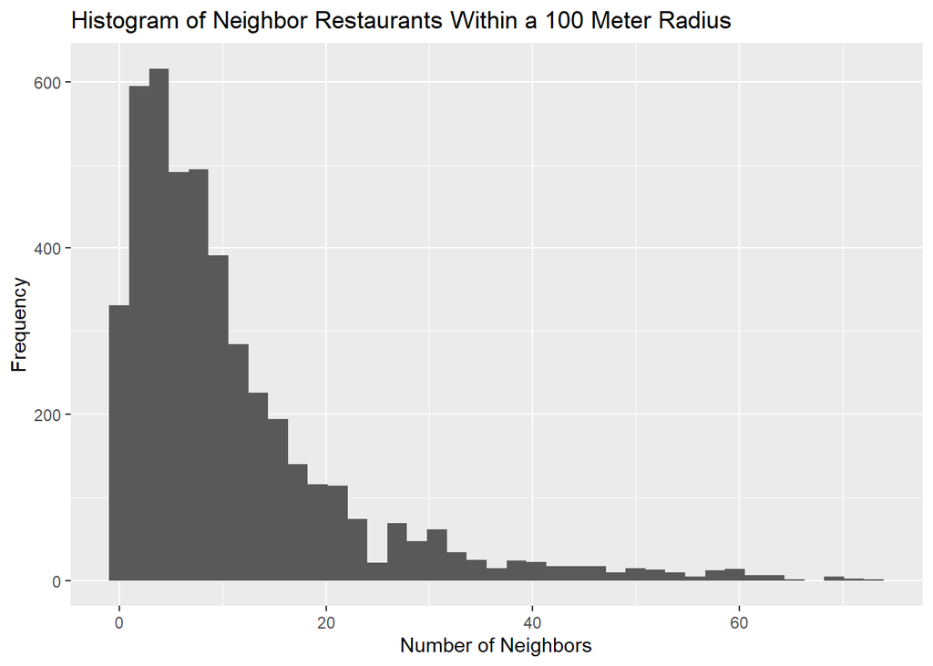

```r
ggplot() +
  geom_histogram(data = ind_rsts, aes(x=n_neighbor), bins=39) +
  labs(title = "Histogram of Neighbor Restaurants Within a 100 Meter Radius",
       x = "Number of Neighbors",
       y = "Frequency")
```

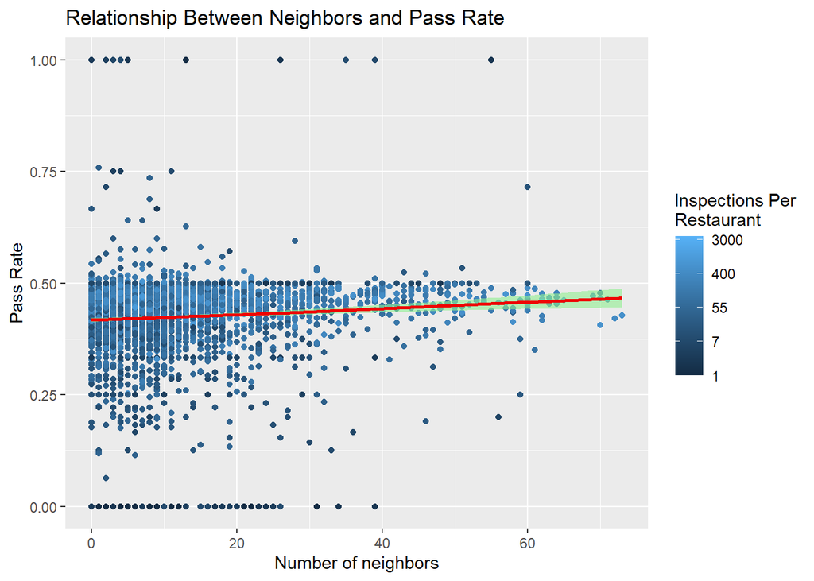

```r
vln_data <- bos_insp |>
  drop_na(viol_status) |>
  mutate(viol_status = if_else(viol_status == "Pass", 1, 0)) |>
  group_by(address_full) |>
  summarize(
    pass_rate = mean(viol_status),
    n_inspections = n()
  )


# join and add log transform because the distribution of n_inspections shows exponential decay

vln_join <- inner_join(ind_rsts, vln_data, by = "address_full") |>
  mutate(
    log_n_inspections = log(n_inspections),
    trans_n_neighbor = sqrt(n_neighbor)
  )


ggplot(data = vln_join, aes(x = n_neighbor, y = pass_rate)) +
  geom_point(aes(color = log_n_inspections)) +
  geom_smooth(method = "gam",
              formula = y ~ s(x, k = 50),
              se = TRUE,
              fill = "lightgreen",
              alpha = 0.6,
              color = "red2") +
  labs(
    title = "Relationship Between Neighbors and Pass Rate",
    x = "Number of neighbors",
    y = "Pass Rate",
    color = "Inspections Per\nRestaurant"
  ) +
  scale_color_gradient(
    breaks = c(0,
               2,
               4,
               6,
               8),
    labels = c("1",
               "7",
               "55",
               "400",
               "3000")
  )
```

This graph corroborates the information we found from the Chi-Squared test. There is a slight positive trend between the number of neighbors and the pass rate for health inspections, seen by the positive trend of the spline. Though slight, we are very confident that this trend exists, seen by the skinniness of the green prediction band. The band gets larger as the number of neighbors increases, but the standard error never exceeds 2.5%. The amount of inspections each restaurant has had total never does not seem to differ with number of neighbors, but does differ slightly by pass rate. The larger the number of inspections a restaurants has, the more they tend to hover around a 50% pass rate.